# (Tücken der) Sentiment-Analyse

7. Februar 2019

## Grundlagen der Sentiment-Analyse

- Grundfrage von Sentiment-Analysen: Wie ist die Stimmung (bezogen auf Objekt X)?
- Einsatzszenarien:
  - Prognose von Aktienkursen
  - Produktbewertungen (z.B. im Netz: Social Media Monitoring)
  - Gutes/schlechtes Charma (Sentiment-Analysen zu tweets von Trump)
- Grundlegende Spielformen der Sentiment-Analyse:
  - *diktionärsbasierte* Verfahren messen anhand von Listen mit positivem / negativem Vokabular
  - *machine learning*-basierte Verfahren klassifizieren mit einem Modell, das trainiert wurde

## Vorbereitungen

Die folgenden Erläuterungen nutzen das `polmineR`-Paket und das `GermaParl`-Korpus.

```r
if (!"polmineR" %in% rownames(installed.packages())) install.packages("polmineR")
drat::addRepo("polmine")
if (!"GermaParl" %in% rownames(installed.packages())) install.packages("GermaParl")
```

Ergänzend nutzen wir die folgenden Pakete:

- `zoo`: Ein Paket zur Arbeit mit Zeitreihen-Daten;
- `magrittr`: Tools, um R-Befehle in einer “Pipe”" hintereinander zu verketten (s.u.);
- `devtools`: Entwicklertools, wir nutzen einen Befehl für den Download einer einzelnen Funktion;

```r
required_packages <- c("zoo", "magrittr", "devtools")
for (pkg in required_packages)
  if (!pkg %in% rownames(installed.packages())) install.packages(pkg)
```

## Los geht’s

- Laden der erforderlichen Pakete.

```r
library(zoo, quietly = TRUE, warn.conflicts = FALSE)
library(devtools, quietly = TRUE)
library(magrittr, quietly = TRUE)
library(data.table, quietly = TRUE)
library(xts, quietly = TRUE)
```

- Laden auch polmineR und aktivieren des GermaParl-Korpus.

```r
library(polmineR)
use("GermaParl")
```

## Wir holen ‘get_sentiws’ von GitHub

- Nutzung des Sentiment-Wortschatz des Leipziger Wortschatz-Projekts, kurz [SentiWS](http://wortschatz.uni-leipzig.de/de/download). (Lizenz: CC-BY-SA-NC)
- Zum vereinfachten Einlesen von SentiWS: Gist bei der GitHub-Präsenz des PolMine-Projekts mit Funktion, die Download erledigt und tabellarische Datenstruktur generiert.

```r
gist_url <- "https://gist.githubusercontent.com/PolMine/70eeb095328070c18bd00ee087272adf/raw/c2eee2f48b11e6d893c19089b444f25b452d2adb/sentiws.R"
devtools::source_url(gist_url) # danach ist Funktion verfügbar
SentiWS <- get_sentiws()
```

- Damit ist mit dem Objekt `SentiWS` das Diktionär verfügbar.

## SentiWS: Ein Blick in die Daten

|  | id | word | base | lemma | pos | weight |
| --- | --- | --- | --- | --- | --- | --- |
| 1 | 1 | Abschluß | True | Abschluß | NN | 0.004 |
| 2 | 1 | Abschlüße | False | Abschluß | NN | 0.004 |
| 3 | 1 | Abschlußs | False | Abschluß | NN | 0.004 |
| 4 | 1 | Abschlußes | False | Abschluß | NN | 0.004 |
| 5 | 1 | Abschlüßen | False | Abschluß | NN | 0.004 |
| 6 | 2 | Abstimmung | True | Abstimmung | NN | 0.004 |
| 7 | 2 | Abstimmungen | False | Abstimmung | NN | 0.004 |
| 8 | 3 | Agilität | True | Agilität | NN | 0.004 |
| 9 | 4 | Aktivität | True | Aktivität | NN | 0.004 |
| 10 | 4 | Aktivitäten | False | Aktivität | NN | 0.004 |

[output cut: 31264 more lines]

## Positives/negatives Vokabular in Wortkontext

- Frage: Wie haben sich die positiven/negativen Konnotationen des “Islams” im Zeitverlauf entwickelt?
- Wir gehen von 10 Worten aus und setzen dies folgendermaßen für unsere R-Sitzung fest.

```r
options("polmineR.left" = 10L)
options("polmineR.right" = 10L)
```

- Über eine “Pipe” generieren wir nun einen `data.frame` (“df”) mit den Zählungen des SentiWS-Vokabulars im Wortumfeld von “Islam”.

```r
df <- context("GERMAPARL", query = "Islam", p_attribute = c("word", "pos"), verbose = FALSE) %>%
  partition_bundle(node = FALSE) %>%
  set_names(s_attributes(., s_attribute = "date")) %>%
  weigh(with = SentiWS) %>% summary()
```

## Tabellarische Daten der Sentiment-Analyse

- Wir arbeiten zunächst nicht mit den Gewichtungen, sondern nur mit dem positiven bzw. negativen Worten. Hier die vereinfachte Tabelle

```r
df <- df[, c("name", "size", "positive_n", "negative_n")]
head(df, n = 12)
```

```
##          name size positive_n negative_n
## 1  1996-03-15   20          0          0
## 2  1996-03-15   20          0          0
## 3  1996-04-18   20          0          2
## 4  1996-05-09   20          0          0
## 5  1996-05-09   20          2          0
## 6  1996-05-09   20          0          0
## 7  1996-06-13   20          0          1
## 8  1996-06-13   20          0          1
## 9  1996-11-27   20          0          1
## 10 1997-02-27   20          0          0
## 11 1997-02-27   20          0          0
## 12 1997-02-27   20          0          1
```

## Aggregation

- Als Namen eines Wortkontexts haben wir oben das Datum des Auftretens unseres Suchbegriffs genutzt. Das ermöglicht es, anhand des Datums für das Jahr hochzuaggregieren.

```r
df[["year"]] <- as.Date(df[["name"]]) %>% format("%Y-01-01")
df_year <- aggregate(df[,c("size", "positive_n", "negative_n")], list(df[["year"]]), sum)
colnames(df_year)[1] <- "year"
```

- Es ist nicht sinnvoll, mit absoluten Häufigkeiten zu arbeiten. Daher fügen wir Spalten ein, die den Anteil des negativen bzw. positiven Vokabulars angeben.

```r
df_year$negative_share <- df_year$negative_n / df_year$size
df_year$positive_share <- df_year$positive_n / df_year$size
```

- Dies wandeln wir in ein Zeitreihen-Objekt um.

```r
Z <- zoo(
  x = df_year[, c("positive_share", "negative_share")],
  order.by = as.Date(df_year[,"year"])
)
```

## Visualisierung

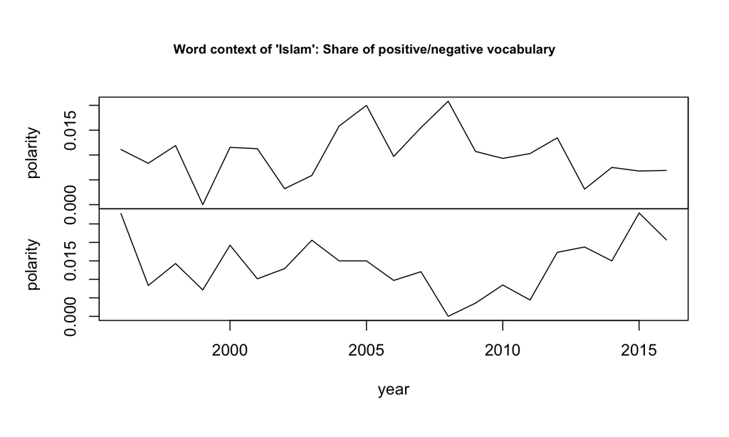

## Wie gut sind eigentlich die Ergebnisse?

- Was verbirgt sich eigentlich hinter den numerischen Werten der ermittelten Sentiment-Scores?
- Wir nutzen die Möglichkeit von polmineR, eine KWIC-Ausgabe entsprechend einer Positiv-Liste (Vektor mit erforderlichen Worten) zu reduzieren, Worte farblich zu codieren und über Tooltips (hier: Wortgewichte) weitergehende Informationen einzublenden.

```r
words_positive <- SentiWS[weight > 0][["word"]]
words_negative <- SentiWS[weight < 0][["word"]]
```

```r
kwic("GERMAPARL", query = "Islam", positivelist = c(words_positive, words_negative)) %>%
  highlight(lightgreen = words_positive, orange = words_negative) %>%
  tooltips(setNames(SentiWS[["word"]], SentiWS[["weight"]]))
```

- Das Ergebnis (ein ‘htmlwidget’) folgt auf der nächsten Folie.

## Sentiment-Analyse: Qualitative Evaluation

|  | left | node | right |
| --- | --- | --- | --- |
| 1 | ethnischen Konflikten-0.0048 , Extremismus , Fundamentalismus unter dem Zeichen des | Islam | und von einem Nährboden für Terrorismus-0.3553 . Dies alles ist |
| 2 | dazu , daß der Iran als Staatsdoktrin den politisch instrumentalisierten | Islam | in der Interpretation von Khomeiny hat , der sich aggressiv-0.4484 |
| 3 | man die Argumentation von Regimen , die sich auf den | Islam | berufen , um ihre Repressionspolitik zu rechtfertigen0.004 . ( Beifall0.3265 |
| 4 | falschen-0.7618 Feindbildern hüten . Der Fundamentalismus umfaßt nicht den ganzen | Islam | . Die erbittertste-0.0048 Auseinandersetzung-0.0603 mit ihm wird innerhalb des Islam |
| 5 | Islam . Die erbittertste-0.0048 Auseinandersetzung-0.0603 mit ihm wird innerhalb des | Islam | selbst geführt0.004 . Die islamischen Länder müssen andererseits wissen , |
| 6 | neben den beiden großen0.3694 Kirchen , dem Judentum und dem | Islam | die Bühne betreten . Nach dem Zusammenbruch-0.0048 des Kommunismus und |
| 7 | nicht mehr standhält . Vielmehr gibt es eine Revitalisierung des | Islam | . Damit sind neue0.004 Herausforderungen-0.0048 an diesen Staat gestellt . |
| 8 | dürfen , dies sei durch religiöse Glaubenssätze geprägt . Der | Islam | -- Herr Zöpel , Sie haben es mit Recht0.004 gesagt |
| 9 | Im nachhinein ist wohl klar0.004 , daß Welajati nicht den | Islam | repräsentiert und daß eine solche Konferenz dringend erforderlich ist . |
| 10 | hüten . Den islamischen Fundamentalismus darf man nicht mit dem | Islam | gleichsetzen . ( Beifall0.3265 bei der CDU/CSU und der F.D.P. |

[output cut: 403 more lines]

## Rezept: Sentiment-Analyse über Partition

- Die strukturelle Annotation CWB-indizierter Korpora macht es in Kombination mit der `partition()`-Methode leicht, das skizziert Verfahren für die Sentiment-Analyse auf Subkorpora anzuwenden, so dass Bewertungsunterschiede (z.B. zwischen Fraktionen und Parteien) analysiert werden können. Im folgenden Beispiel schränken wir das GermaParl-Korpus auf die Redner von CDU und CSU ein.

```r
p <- partition("GERMAPARL", parliamentary_group = "CDU/CSU", interjection = FALSE)
```

- In einem etwas gestrafften Verfahren generieren wird die Daten für die Sentiment-Analyse. Zuerst generieren wir den `data.frame` mit den absoluten Zählungen.

```r
df <- context(p, query = "Islam", p_attribute = c("word", "pos"), verbose = FALSE) %>%
  partition_bundle(node = FALSE) %>%
  set_names(s_attributes(., s_attribute = "date")) %>%
  weigh(with = SentiWS) %>%
  summary() %>%
  subset(select = c("name", "size", "positive_n", "negative_n"))
```

## Aggregation

- Daraus wird nun ein Zeitreihen-Objekt.

```r
time_index <- as.Date(df[["name"]]) #
df[["name"]] <- NULL # Spalte 'name' nicht mehr benötig, wird gelöscht
tseries <- as.xts(df, order.by = time_index) # Umwandlung in Zeitreihen-Objekt
```

- Wir führen jetzt eine wiederverwendbare Funktion zur Aggregation der Zeitreihen ein. Mit dieser kann man nach “week”, “month”, “quarter” oder “year” aggregieren.

```r
aggregate_time_series <- function(x, aggregation){
  y <- switch(
    aggregation,
    week = aggregate(x, {a <- lubridate::ymd(paste(lubridate::year(index(x)), 1, 1, sep = "-")); lubridate::week(a) <- lubridate::week(index(x)); a}),
    month = aggregate(x, as.Date(as.yearmon(index(x)))),
    quarter = aggregate(x, as.Date(as.yearqtr(index(x)))),
    year = aggregate(x, as.Date(sprintf("%s-01-01", gsub("^(\\d{4})-.*?$", "\\1", index(x)))))
    )
  y$negative_share <- -1 * (y$negative_n / y$size)
  y$positive_share <- y$positive_n / y$size
  as.xts(y)
}
```

## Aggregationsniveau Jahr

- In einem ersten Durchlauf sehen wir das Ergebnis auf dem Ergebnis des Aggregationsniveau eines Jahres an.

```r
aggr <- aggregate_time_series(tseries, "year")
```

- Wir erzeugen ein Zeitreihen-Digramm.

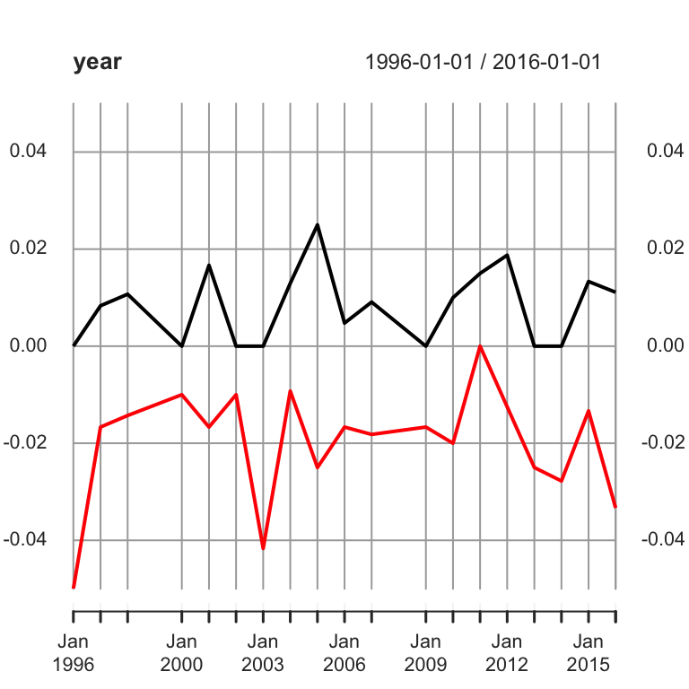

```r
plot(
  aggr[,c("positive_share", "negative_share")],
  multi.panel = FALSE,
  ylab = "polarity",
  xlab = "year",
  main = "year",
  cex = 0.5,
  cex.main = 0.5,
  ylim = c(-0.05, 0.05)
  )
```

## Verschiedene Aggregationen

- Um den Vergleich verschiedener Aggregationen zu haben zeigt die folgende Folie die Aggregation nach Woche, Monat, Quartal und Jahr.

```r
par(mfrow = c(2,2))
for (aggregation_level in c("week", "month", "quarter", "year")){
  x <- aggregate_time_series(tseries, aggregation_level)
  x <- x[,c("positive_share", "negative_share")]

  y <- plot(
    x,
    multi.panel = FALSE,
    ylab = "polarity",
    xlab = "year",
    main = aggregation_level,
    cex = 0.3,
    cex.main = 0.3,
    ylim = c(-0.05, 0.05),
    type = "l"
  )
  show(y)
}
```

## Sentiment-Analyse zu “Islam”

### Aggregation nach Woche, Monat, Quartal, Jahr

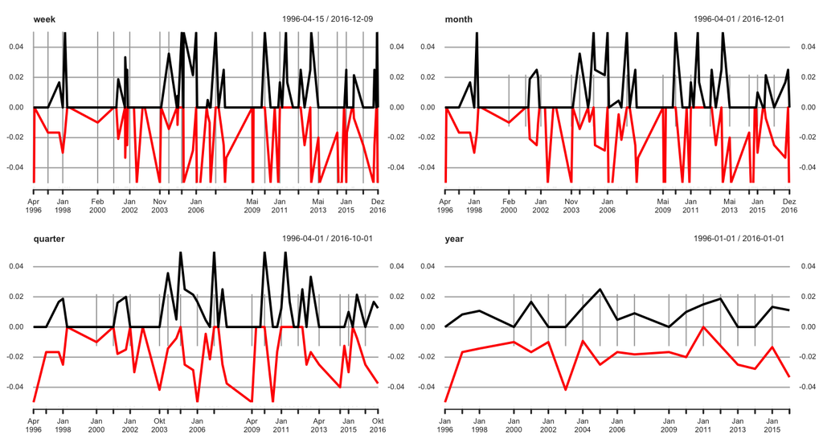

## Diskussion

- Wir interpretieren Sie die Ergebnisse der Zeitreihen-Analyse?
- Wie valide sind die Ergebnisse?
- Ist der Übergang zur Arbeit mit Wort-Gewichten sinnvoll oder erforderlich?